# Project: Communicate Data Findings (2017-fordgobike-tripdata)

## by Sidhi Agarwal

## Investigation Overview

> The overall goal is to show some analysis that has been done with this bike share data. We will try to detect several patterns in the data to have a better understading of how the users behave, when do they use the service, which factors have influence in the frequency of usage and how these factors interact with each other.

## Dataset Overview

### Each trip is anonymized and includes:

> - Trip Duration (seconds)
> - Start Time and Date
> - End Time and Date
> - Start Station ID
> - Start Station Name
> - Start Station Latitude
> - Start Station Longitude
> - End Station ID
> - End Station Name
> - End Station Latitude
> - End Station Longitude
> - Bike ID
> - User Type (Subscriber or Customer – “Subscriber” = Member or “Customer” = Casual) ###### There are 155686 records and 13 columns

## Univariate Exploration of Trip Duration

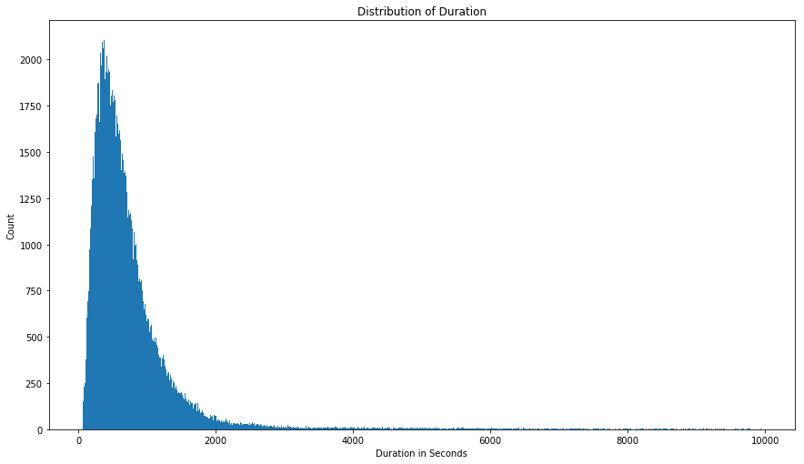

```python
# Removing the outliers
main = main[(np.abs(stats.zscore(main.duration_sec)) < 3)]

# Visualization
graph = main.duration_sec
plt.figure(figsize=[14.70, 8.27])
plt.hist(graph,bins=1000);
plt.title("Distribution of Duration")
plt.xlabel('Duration in Seconds')
plt.ylabel('Count');
```

## The effect of User Type on Trip Duration

> This visualization represents the relationship between User Type and Trip Duration, indicating that regular users take lesser time to complete rides.

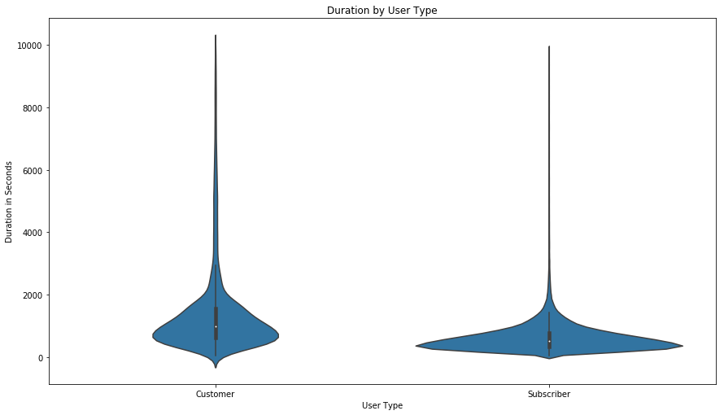

```python
# User Type and Duration
plt.figure(figsize=[14.70, 8.27])
sb.violinplot(data=main,x='user_type',y='duration_sec', color=base_color);
plt.title("Duration by User Type")
plt.xlabel('User Type')
plt.ylabel('Duration in Seconds');
```

## How does the hourly usage vary during a week for customers and subscribers?

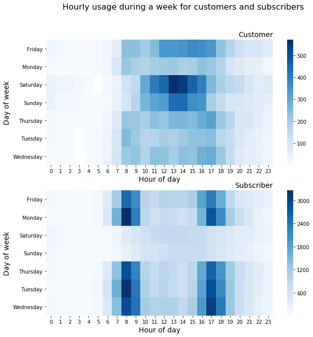

```python
# Visualization
plt.figure(figsize=[10, 10]);
plt.suptitle('Hourly usage during a week for customers and subscribers', fontsize=16)

plt.subplot(2, 1, 1)
customers = main.query('user_type == "Customer"')
ct_counts = customers.groupby(['start_day_of_week', 'start_hour_of_day']).size()
ct_counts = ct_counts.reset_index(name='count')
ct_counts = ct_counts.pivot(index='start_day_of_week', columns='start_hour_of_day', values='count')
sb.heatmap(ct_counts, cmap="Blues");
plt.title('Customer', loc='right', fontsize=14);
plt.xlabel('Hour of day', fontsize=14);
plt.ylabel('Day of week', fontsize=14);

plt.subplot(2, 1, 2)
subscribers = main.query('user_type == "Subscriber"')
st_counts = subscribers.groupby(['start_day_of_week', 'start_hour_of_day']).size()
st_counts = st_counts.reset_index(name='count')
st_counts = st_counts.pivot(index='start_day_of_week', columns='start_hour_of_day', values='count')
sb.heatmap(st_counts, cmap="Blues");
plt.title('Subscriber', loc='right', fontsize=14);
plt.xlabel('Hour of day', fontsize=14);
plt.ylabel('Day of week', fontsize=14);
```

## Conclusion

> There is a difference in usage patterns by day of week and hours for customers and subscribers. Relationship between User Type and Trip Duration, indicating that regular users take lesser time to complete rides.